# hw02

Victor Huang

1/20/2022

## Q1. (Exercise 4.6)

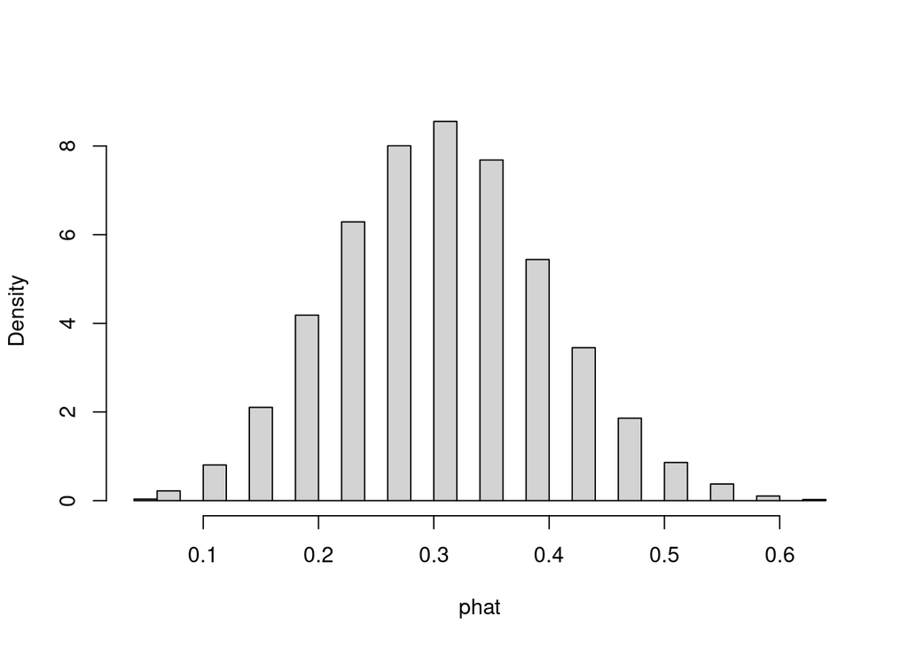

```r
set.seed(69420)
Recidivism <- read.csv("https://sites.google.com/site/chiharahesterberg/data2/Recidivism.csv")
N <- 10^4
phat <- numeric(N)
for (i in 1:N)
{
  samp <- sample(Recidivism$Recid, 25)
  phat[i] <- mean(samp == "Yes")
}
hist(phat, freq = FALSE, main = NULL, breaks = 30)
```

```r
mean(phat) #0.315
```

```
## [1] 0.317352
```

```r
sd(phat) #0.092
```

```
## [1] 0.09227394
```

3. Using the following equation $SE = \sqrt{\frac{\hat p (1 - \hat p)}{n}} = \sqrt{\frac{0.316(1-0.316)}{250}} = 0.02940367$ we get that theoretical standard error to be 0.02940367. This pair of theoretical standard error and estimated standard error is closer than the previous one with n = 25 cases.

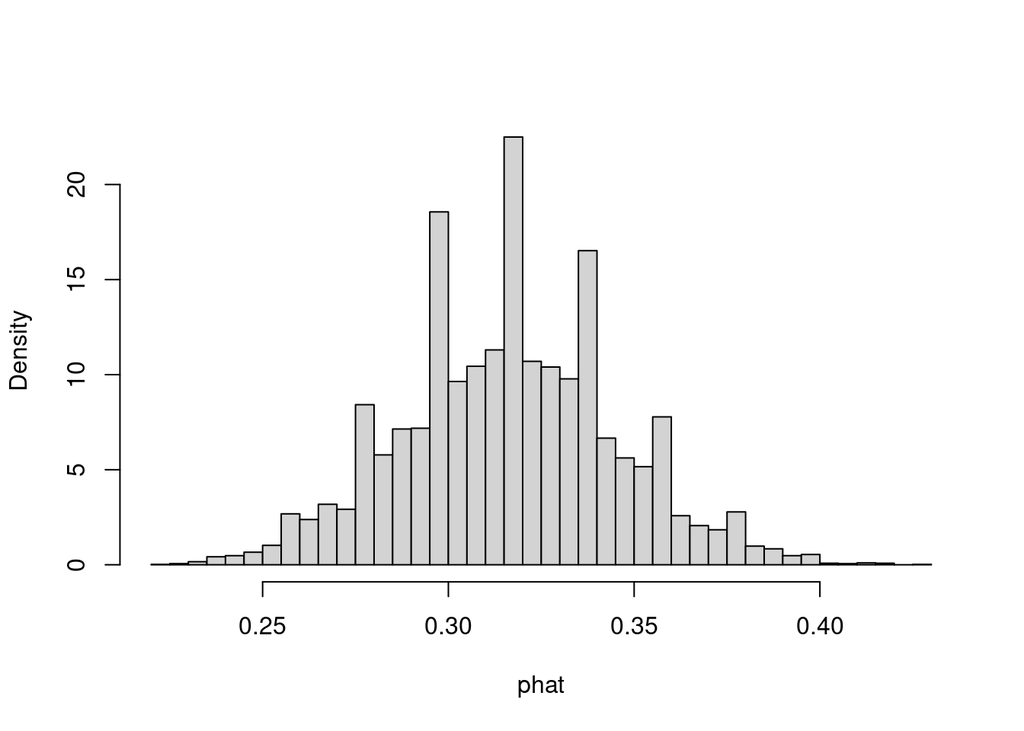

```r
set.seed(69420)
Recidivism <- read.csv("https://sites.google.com/site/chiharahesterberg/data2/Recidivism.csv")
N <- 10^4
phat <- numeric(N)
for (i in 1:N)
{
  samp <- sample(Recidivism$Recid, 250)
  phat[i] <- mean(samp == "Yes")
}
hist(phat, freq = FALSE, main = NULL, breaks = 30)
```

```r
mean(phat)
```

```
## [1] 0.3169336
```

```r
sd(phat)
```

```
## [1] 0.02905113
```

## Q2. (Exercise 4.7)

1. Looking at the histogram below, we see that the data is skewed to the right, We get a mean of 11.7379 and a standard deviation 41.6305

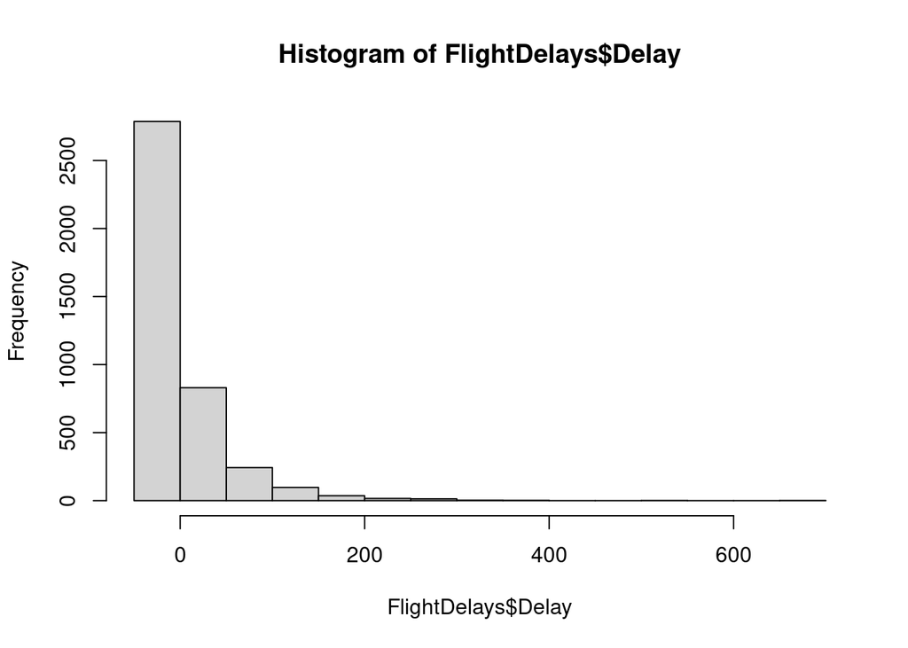

```r
FlightDelays <- read.csv("https://sites.google.com/site/chiharahesterberg/data2/FlightDelays.csv")
hist(FlightDelays$Delay)
```

```r
mean(FlightDelays$Delay)
```

```
## [1] 11.7379
```

```r
sd(FlightDelays$Delay)
```

```
## [1] 41.6305
```

2. Looking at the histogram below, we see that the simulated sampling distribution is skewed to the right, We get an estimated mean of 11.64506 and a standard error 8.281396.

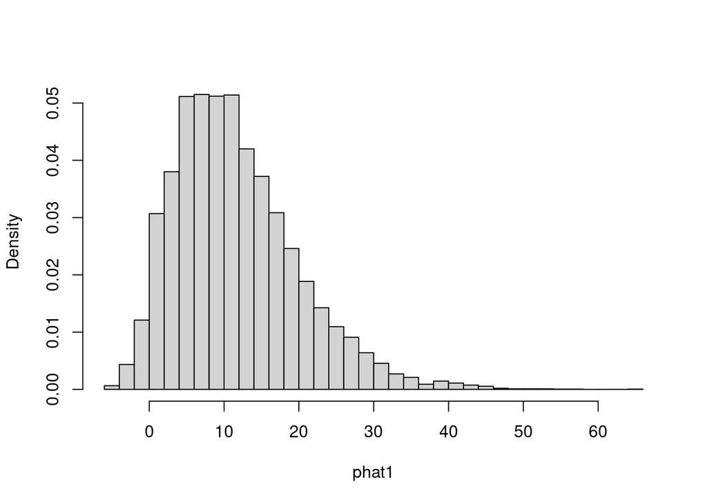

```r
set.seed(69420)
FlightDelays <- read.csv("https://sites.google.com/site/chiharahesterberg/data2/FlightDelays.csv")
N <- 10^4
phat1 <- numeric(N)
for (i in 1:N)
{
samp <- sample(FlightDelays$Delay, 25)
phat1[i] <- mean(samp)
}
hist(phat1, freq = FALSE, main = NULL, breaks = 30)
```

```r
mean(phat1)
```

```
## [1] 11.64506
```

```r
sd(phat1)
```

```
## [1] 8.281396
```

3. Our estimated standard error of 8.281396 is very far off from our theoretical standard error of 0.6558627

```r
TSE <- sd(FlightDelays$Delay)/sqrt(4029)
TSE
```

```
## [1] 0.6558627
```

4. Our estimated standard erorr is now 2.53198, which is much closer to the theoretical standard error of 0.6558627 compared to when n = 25

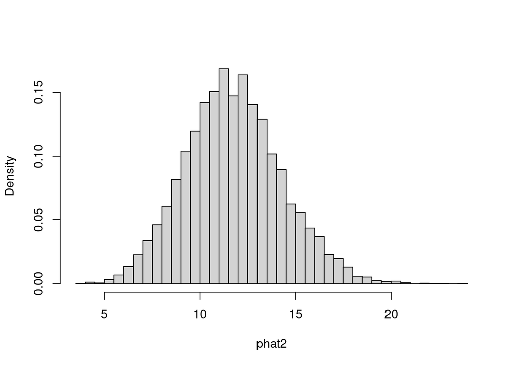

```r
set.seed(69420)
FlightDelays <- read.csv("https://sites.google.com/site/chiharahesterberg/data2/FlightDelays.csv")
N <- 10^4
phat2 <- numeric(N)
for (i in 1:N)
{
samp <- sample(FlightDelays$Delay, 250)
phat2[i] <- mean(samp)
}
hist(phat2, freq = FALSE, main = NULL, breaks = 30)
```

```r
mean(phat2)
```

```
## [1] 11.75512
```

```r
sd(phat2)
```

```
## [1] 2.53198
```

## Q3. (Exercise 4.12)

Looking at the calculations below, we see that $P(\hat X \leq 4.6) = 0.02385744$

```r
n <- 20
mean <- 6
variance <- 10
val <- (4.6 - 6)/(sqrt(10)/sqrt(20))
pnorm(val)
```

```
## [1] 0.02385744
```

## Q4. (Exercise 4.20)

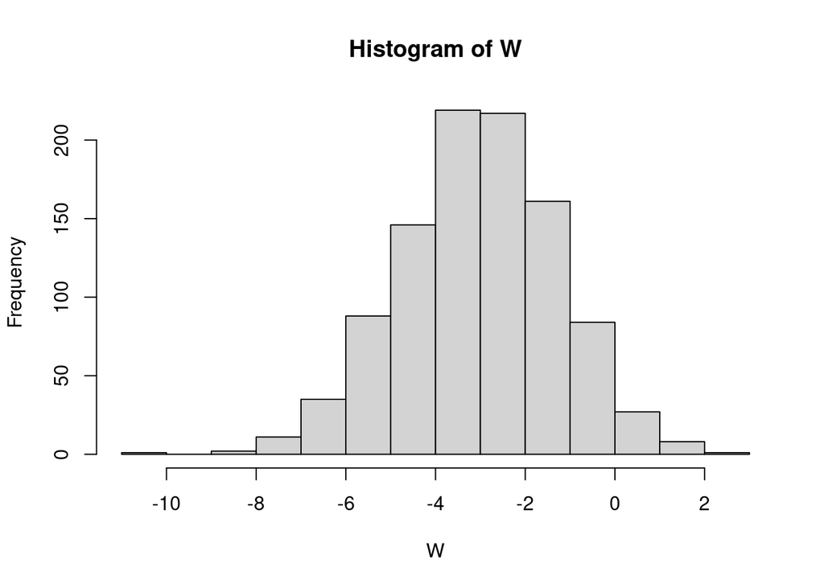

```r
set.seed(69420)
W <- numeric(1000)
for (i in 1:1000)
{
x <- rnorm(9,7,3)
y <- rnorm(12,10,5)
W[i] <- mean(x) - mean(y)
}
hist(W)
```

```r
mean(W)
```

```
## [1] -3.046227
```

```r
sum((W - mean(W))^2/ length(W))
```

```
## [1] 3.050577
```

3. We get that $P(W < -1.5) = 0.82$, our exact answer is 0.804, which is pretty close to our estimated answer

```r
prob<- (-1.5 + 3)/(sqrt(3.083))
bleh <- pnorm(prob)
bleh
```

```
## [1] 0.8035274
```

```r
mean(W < -1.5)
```

```
## [1] 0.82
```

## Q5. (Exercise 4.14)

We get the probability that between 220 and 230 people, 29.6% of people will have a high school diploma

```r
n <- 800
p <- 0.286
pbinom(220, 800, 0.286)
```

```
## [1] 0.259103
```

```r
pbinom(230, 800, 0.286)
```

```
## [1] 0.5550674
```

```r
pbinom(230, 800, 0.286) - pbinom(220, 800, 0.286)
```

```
## [1] 0.2959644
```

## Q6. (Exercise 4.28)

$$f(x) = 3x^2$$
$$P(X \leq x) = \int_0^x3x^2dx$$
$$P(X \leq x) = x^3$$
a)
$$f(x_{min}) = n[1-x_{1}^n]^{n-1}f(x_n)$$
$$f(x_{min}) = n[1-x_1^3]^{n-1}3x_n^2$$
$$f(x_{min}) = 3n[1-x_1^3]^{n-1}x_n^2 (0 \leq x \leq 1)$$
b)
$$f(x_{max}) = n[f(x_n)]^{n-1}f(x_n)$$
$$f(x_{max}) = 3n \cdot x_n^{n-1}x_n^2$$
$$f(x_{max}) = 3n \cdot x_n^{3n-1} (0 \leq x_n \leq 1)$$
c)
$$P[x_{max} > 0.92] = \int_{0.92}^13 \cdot 10x_n^{3 \cdot 10 -1}dx_n$$
$$...$$

$$P[x_{max} > 0.92] = 1 - (0.92)^{30}$$

## Q7. (Exercise 5.9)

1. The plot seems normally distributed with the estimated mean at 24 and estimated standard error at 0.688

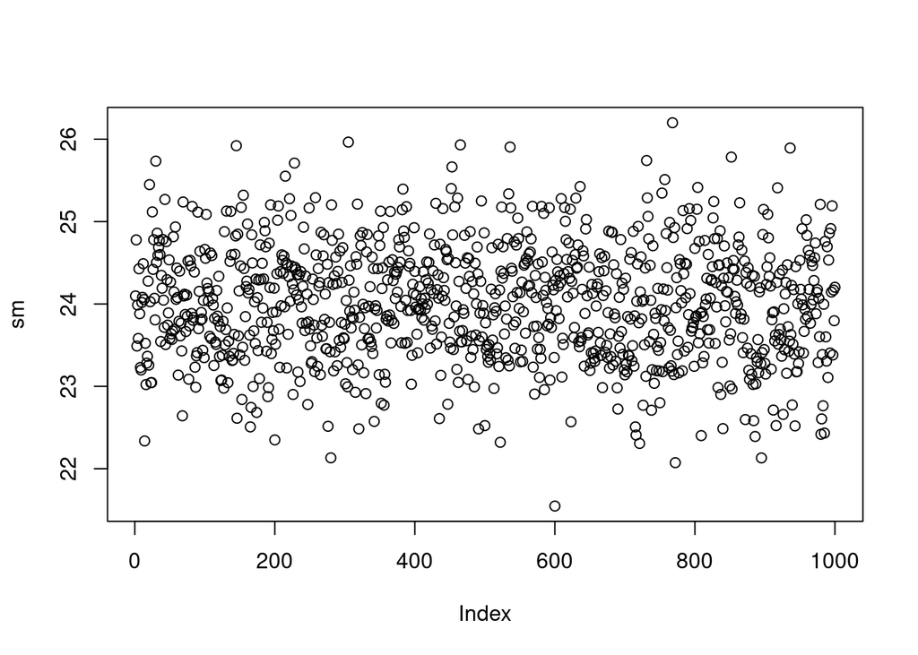

```r
set.seed(69420)
sm <- numeric(1000)
for (i in 1:1000)
{
sm[i] = mean(rgamma(200,6,0.25))
}
plot(sm)
```

```r
mean(sm)
```

```
## [1] 24.00057
```

```r
sd(sm)
```

```
## [1] 0.6880968
```

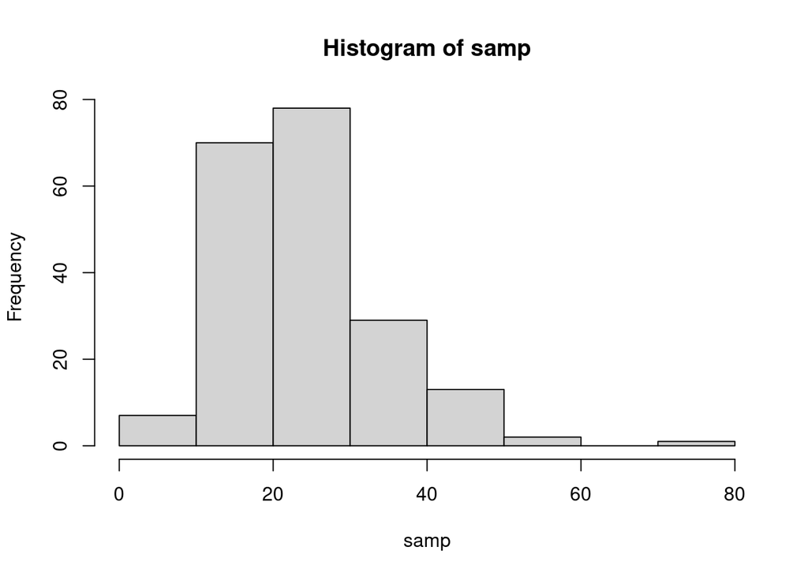

```r
set.seed(69420)
samp <- rgamma(200,6,0.25)
hist(samp)
```

```r
mean(samp)
```

```
## [1] 24.09766
```

```r
sd(samp)
```

```
## [1] 10.22827
```

3. Bootstrap mean is 24 and standard error is 0.221

```r
set.seed(69420)
sm1 <- numeric(1000)
for (i in 1:1000)
{
sm1[i] = mean(rgamma(2000,6,0.25))
}
mean(sm1)
```

```
## [1] 24.00756
```

```r
sd(sm1)
```

```
## [1] 0.2205201
```

4. The mean for sampling distribution and bootstrap distribution are very close (approximately 24 for both). The standard error is a bit different with smapling distribution having a 0.6881 SE and bootstrap distribution having an 0.221 SE.

```r
data.frame(
    Distribution = c("Sampling distribution",
                     "Bootstrap distribution"),
    Mean = c(mean(sm), mean(sm1)),
    SE = c(sd(sm), sd(sm1))
)
```

```
##             Distribution     Mean        SE
## 1  Sampling distribution 24.00057 0.6880968
## 2 Bootstrap distribution 24.00756 0.2205201
```

5. As the sample size gets smaller, shilw the means stay about the same, the SE gets significantly worse and more different as sample size decreases

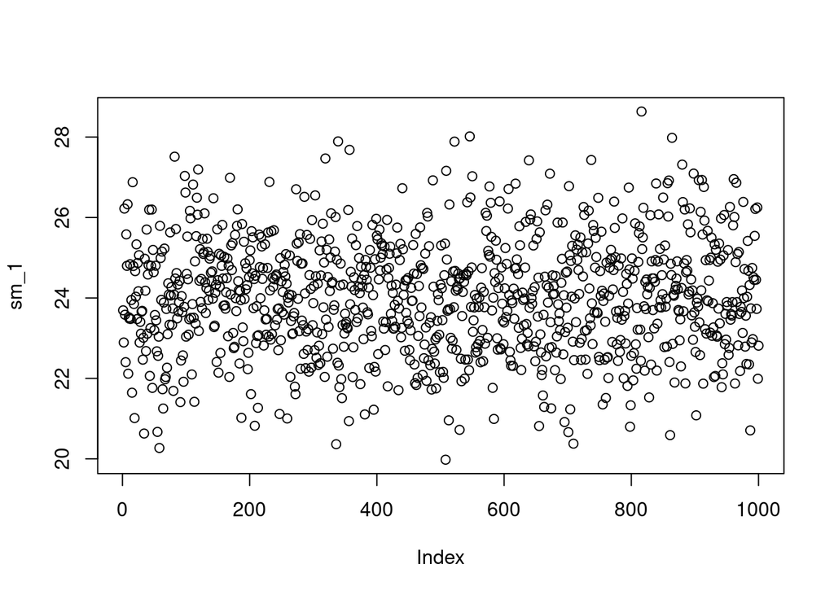

```r
set.seed(69420)
sm_1 <- numeric(1000)
for (i in 1:1000)
{
sm_1[i] = mean(rgamma(50,6,0.25))
}
plot(sm_1)
```

```r
mean(sm_1)
```

```
## [1] 24.02785
```

```r
sd(sm_1)
```

```
## [1] 1.39933
```

```r
sm1_1 <- numeric(1000)
for (i in 1:1000)
{
sm1_1[i] = mean(rgamma(2000,6,0.25))
}
mean(sm1_1)
```

```
## [1] 24.00665
```

```r
sd(sm1_1)
```

```
## [1] 0.2194553
```

```r
data.frame(
    Distribution = c("Sampling distribution",
                     "Bootstrap distribution"),
    Mean = c(mean(sm_1), mean(sm1_1)),
    SE = c(sd(sm_1), sd(sm1_1))
)
```

```
##             Distribution     Mean        SE
## 1  Sampling distribution 24.02785 1.3993302
## 2 Bootstrap distribution 24.00665 0.2194553
```

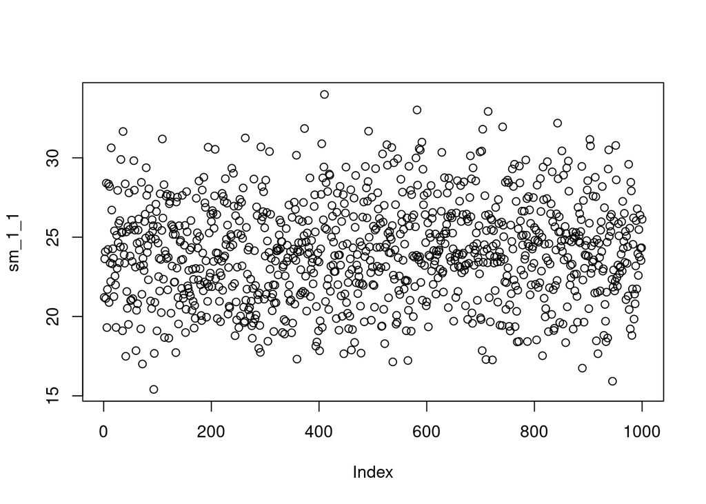

```r
set.seed(69420)
sm_1_1 <- numeric(1000)
for (i in 1:1000)
{
sm_1_1[i] = mean(rgamma(10,6,0.25))
}
plot(sm_1_1)
```

```r
mean(sm_1_1)
```

```
## [1] 24.08153
```

```r
sd(sm_1_1)
```

```
## [1] 3.117634
```

```r
sm1_1_1 <- numeric(1000)
for (i in 1:1000)
{
sm1_1_1[i] = mean(rgamma(2000,6,0.25))
}
mean(sm1_1_1)
```

```
## [1] 24.00776
```

```r
sd(sm1_1_1)
```

```
## [1] 0.2196423
```

```r
data.frame(
    Distribution = c("Sampling distribution",
                     "Bootstrap distribution"),
    Mean = c(mean(sm_1_1), mean(sm1_1_1)),
    SE = c(sd(sm_1_1), sd(sm1_1_1))
)
```

```
##             Distribution     Mean        SE
## 1  Sampling distribution 24.08153 3.1176340
## 2 Bootstrap distribution 24.00776 0.2196423
```

## Q8. (Exercise 5.11)

1. The histogram is extremely right skewed with a boxplot that fits that as well. The summary for the chlorine consist of min = 1.00, 1st quantile = 5.00, median = 14.05, Mean = 78.31, 3rd quantile = 55.70, and max = 1550.00

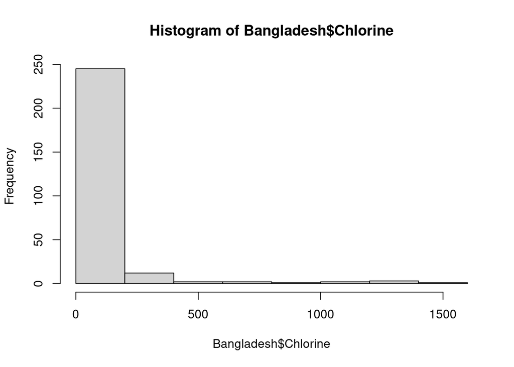

```r
set.seed(69420)
Bangladesh <- read.csv("https://sites.google.com/site/chiharahesterberg/data2/Bangladesh.csv")
Bangladesh <- na.omit(Bangladesh)
hist(Bangladesh$Chlorine)
```

```r
summary(Bangladesh$Chlorine)
```

```
##    Min. 1st Qu.  Median    Mean 3rd Qu.    Max.
##    1.00    5.00   14.05   78.31   55.70 1550.00
```

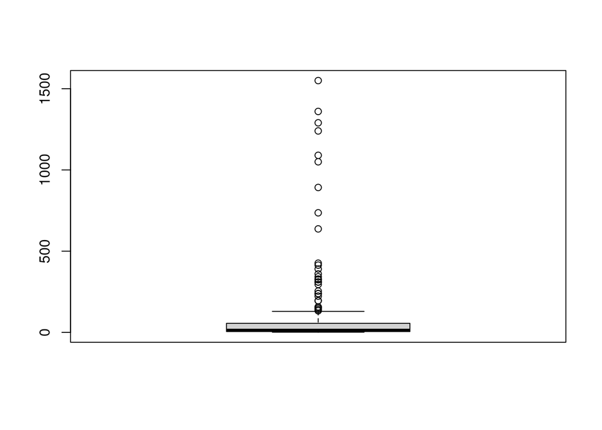

```r
boxplot(Bangladesh$Chlorine)
```